# FML Assignment_4

# Kmeans Clustering

For getting the best value of K(no. of clusters) for kmeans

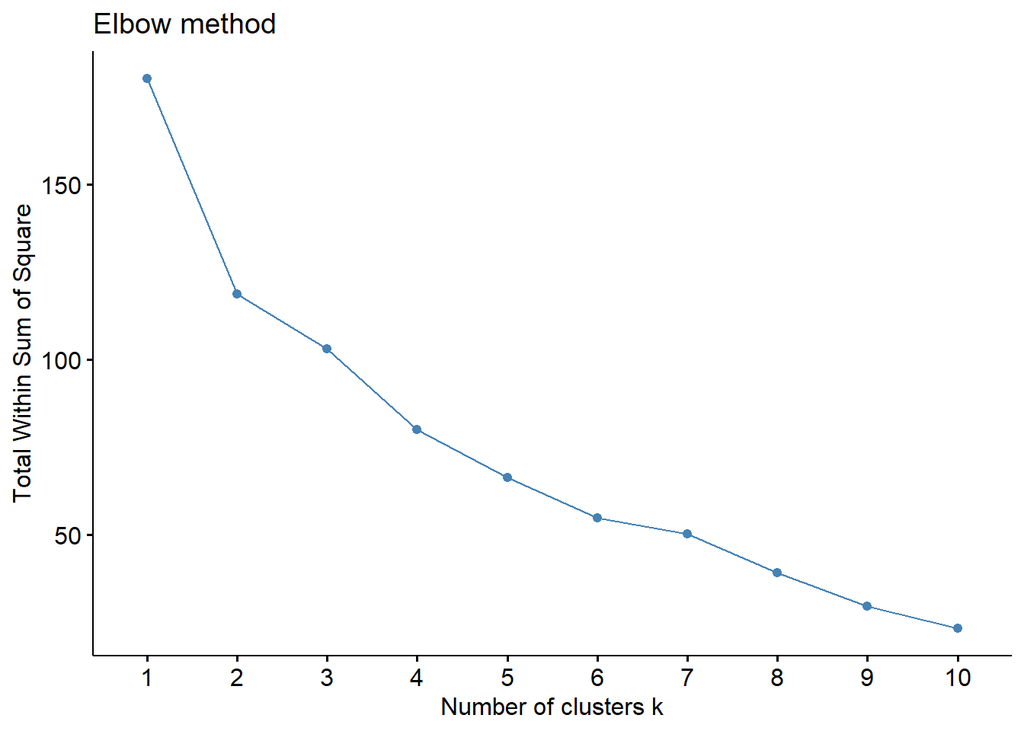

```r
# sum of squares method
fviz_nbclust(scaled.data, kmeans, method = "wss") + ggtitle("Elbow method")
```

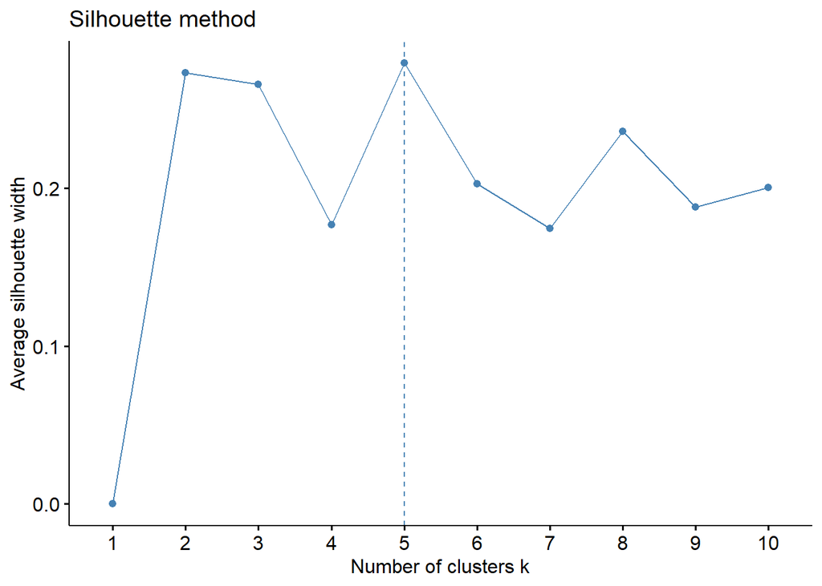

```r
# silhouette method
fviz_nbclust(scaled.data, kmeans, method = "silhouette") + ggtitle("Silhouette method")
```

from the plot of WSS(Sum of squares) or elbow method, we can see that the curve was bent(as elbow) at point 2, so we have to consider the k value as 2. however it is still unclear due to less sharpness in the graphical representation.

```r
# consider k=2
k <- 2
set.seed(159)
# kmeans algorithm
k_wss <- kmeans(scaled.data, centers = k, nstart=21)
k_wss
```

```
## K-means clustering with 2 clusters of sizes 11, 10
##
## Cluster means:
##   Market_Cap       Beta   PE_Ratio        ROE        ROA Asset_Turnover
## 1  0.6733825 -0.3586419 -0.2763512  0.6565978  0.8344159      0.4612656
## 2 -0.7407208  0.3945061  0.3039863 -0.7222576 -0.9178575     -0.5073922
##     Leverage Rev_Growth Net_Profit_Margin
## 1 -0.3331068 -0.2902163         0.6823310
## 2  0.3664175  0.3192379        -0.7505641
##
## Clustering vector:
##  ABT  AGN  AHM  AZN  AVE  BAY  BMY CHTT  ELN  LLY  GSK  IVX  JNJ  MRX  MRK  NVS
##    1    2    2    1    2    2    1    2    2    1    1    2    1    2    1    1
##  PFE  PHA  SGP  WPI  WYE
##    1    2    1    2    1
##
## Within cluster sum of squares by cluster:
## [1] 43.30886 75.26049
##  (between_SS / total_SS =  34.1 %)
##
## Available components:
##
## [1] "cluster"      "centers"      "totss"        "withinss"     "tot.withinss"
## [6] "betweenss"    "size"         "iter"         "ifault"
```

```r
# To get the centroids of the clusters
cat("These are the centers of the clusters", "\n")
```

```
## These are the centers of the clusters
```

```r
k_wss$centers
```

```
##   Market_Cap       Beta   PE_Ratio        ROE        ROA Asset_Turnover
## 1  0.6733825 -0.3586419 -0.2763512  0.6565978  0.8344159      0.4612656
## 2 -0.7407208  0.3945061  0.3039863 -0.7222576 -0.9178575     -0.5073922
##     Leverage Rev_Growth Net_Profit_Margin
## 1 -0.3331068 -0.2902163         0.6823310
## 2  0.3664175  0.3192379        -0.7505641
```

```r
# Get the size of each cluster
cat("The Size of the each cluster is", "\n")
```

```
## The Size of the each cluster is
```

```r
k_wss$size
```

```
## [1] 11 10
```

```r
# To get which point belongs to which cluster
k_wss$cluster
```

```
##  ABT  AGN  AHM  AZN  AVE  BAY  BMY CHTT  ELN  LLY  GSK  IVX  JNJ  MRX  MRK  NVS
##    1    2    2    1    2    2    1    2    2    1    1    2    1    2    1    1
##  PFE  PHA  SGP  WPI  WYE
##    1    2    1    2    1
```

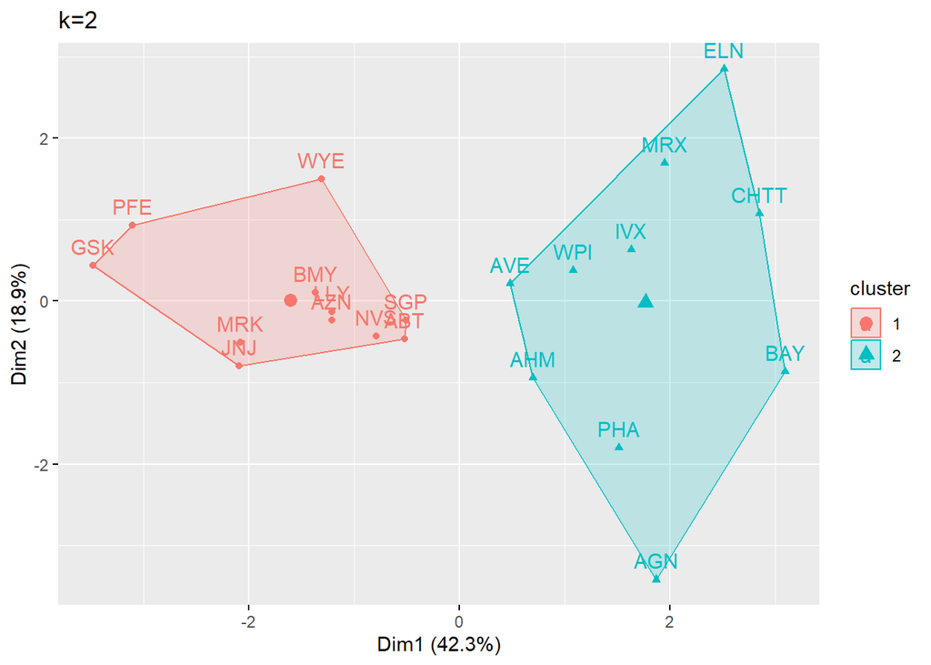

```r
# Visualization of clusters
fviz_cluster(k_wss,data = scaled.data) + ggtitle("k=2")
```

from the output of this kmeans clustering with k value of 2. we can see that 11 companies comes under one cluster and the remaining 10 comes under another cluster, by taking all the numerical variables as these all are the financial measures are to be considered to know the equity, as equity depends on Market capital, net profit, return on assets, asset turnover, etc. And from the clusters we can see that some of the points like AGN, ELN, GSK, etc.. are far away from the centroids, which shows us that the number of clusters taken was not enough. ***** from the plot of silhouette method, we can see that the maximum average silhouette width is at point 5, so we have to consider the k value as 5.

```r
# consider k=5
k <- 5
set.seed(159)
# kmeans algorithm
k_sil <- kmeans(scaled.data, centers = k, nstart=20)
k_sil
```

```
## K-means clustering with 5 clusters of sizes 4, 2, 4, 3, 8
##
## Cluster means:
##    Market_Cap       Beta    PE_Ratio        ROE        ROA Asset_Turnover
## 1 -0.76022489  0.2796041 -0.47742380 -0.7438022 -0.8107428     -1.2684804
## 2 -0.43925134 -0.4701800  2.70002464 -0.8349525 -0.9234951      0.2306328
## 3  1.69558112 -0.1780563 -0.19845823  1.2349879  1.3503431      1.1531640
## 4 -0.87051511  1.3409869 -0.05284434 -0.6184015 -1.1928478     -0.4612656
## 5 -0.03142211 -0.4360989 -0.31724852  0.1950459  0.4083915      0.1729746
##      Leverage Rev_Growth Net_Profit_Margin
## 1  0.06308085  1.5180158      -0.006893899
## 2 -0.14170336 -0.1168459      -1.416514761
## 3 -0.46807818  0.4671788       0.591242521
## 4  1.36644699 -0.6912914      -1.320000179
## 5 -0.27449312 -0.7041516       0.556954446
##
## Clustering vector:
##  ABT  AGN  AHM  AZN  AVE  BAY  BMY CHTT  ELN  LLY  GSK  IVX  JNJ  MRX  MRK  NVS
##    5    2    5    5    1    4    5    4    1    5    3    4    3    1    3    5
##  PFE  PHA  SGP  WPI  WYE
##    3    2    5    1    5
##
## Within cluster sum of squares by cluster:
## [1] 12.791257  2.803505  9.284424 15.595925 21.879320
##  (between_SS / total_SS =  65.4 %)
##
## Available components:
##
## [1] "cluster"      "centers"      "totss"        "withinss"     "tot.withinss"
## [6] "betweenss"    "size"         "iter"         "ifault"
```

```r
# To get the centroids of the clusters
cat("These are the centers of the clusters", "\n")
```

```
## These are the centers of the clusters
```

```r
k_sil$centers
```

```
##    Market_Cap       Beta    PE_Ratio        ROE        ROA Asset_Turnover
## 1 -0.76022489  0.2796041 -0.47742380 -0.7438022 -0.8107428     -1.2684804
## 2 -0.43925134 -0.4701800  2.70002464 -0.8349525 -0.9234951      0.2306328
## 3  1.69558112 -0.1780563 -0.19845823  1.2349879  1.3503431      1.1531640
## 4 -0.87051511  1.3409869 -0.05284434 -0.6184015 -1.1928478     -0.4612656
## 5 -0.03142211 -0.4360989 -0.31724852  0.1950459  0.4083915      0.1729746
##      Leverage Rev_Growth Net_Profit_Margin
## 1  0.06308085  1.5180158      -0.006893899
## 2 -0.14170336 -0.1168459      -1.416514761
## 3 -0.46807818  0.4671788       0.591242521
## 4  1.36644699 -0.6912914      -1.320000179
## 5 -0.27449312 -0.7041516       0.556954446
```

```r
# Get the size of each cluster
cat("The Size of the each cluster is",  "\n")
```

```
## The Size of the each cluster is
```

```r
k_sil$size
```

```
## [1] 4 2 4 3 8
```

```r
# To get which point belongs to which cluster
k_sil$cluster
```

```
##  ABT  AGN  AHM  AZN  AVE  BAY  BMY CHTT  ELN  LLY  GSK  IVX  JNJ  MRX  MRK  NVS
##    5    2    5    5    1    4    5    4    1    5    3    4    3    1    3    5
##  PFE  PHA  SGP  WPI  WYE
##    3    2    5    1    5
```

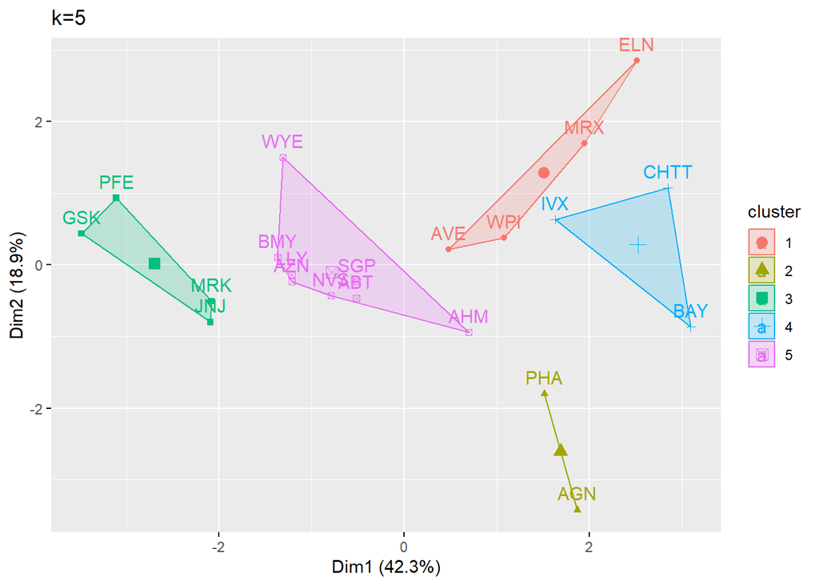

```r
# Visualization of clusters
fviz_cluster(k_sil, scaled.data) + ggtitle("k=5")
```

# DBSCAN Clustering

To get the best value of radius or eps.

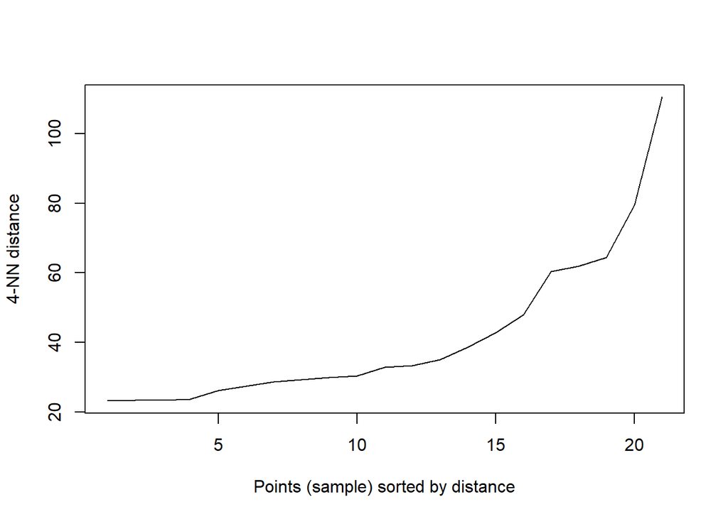

```r
# Graph to get the best value of radius at min points of 4.
dbscan::kNNdistplot(clust.data, k=4)
```

KNN-dist plot is used ro determine the optimal value of radius for DBSCAN clustering, we need to take the radius from where the curve was bent. From the above Plot, we can see that the curve was bent at distance between 20 and 40. so, consider the radius or EPS value as 30 at minimum points of 4.

```r
# DBSCAN Algorithm at eps=30 and minpts =4
dbs <- dbscan::dbscan(clust.data, eps = 30, minPts = 4)

# Output of the clusters
print(dbs)
```

```
## DBSCAN clustering for 21 objects.
## Parameters: eps = 30, minPts = 4
## Using euclidean distances and borderpoints = TRUE
## The clustering contains 2 cluster(s) and 6 noise points.
##
## 0 1 2
## 6 8 7
##
## Available fields: cluster, eps, minPts, dist, borderPoints
```

```r
# To get which point belongs to which cluster
print(dbs$cluster)
```

```
##  [1] 1 0 2 1 1 2 1 2 2 1 0 2 0 2 0 1 0 0 1 2 1
```

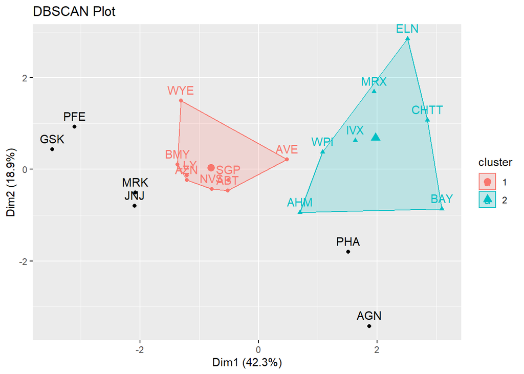

```r
# Visualization of clusters
fviz_cluster(dbs, clust.data) + ggtitle("DBSCAN Plot")
```

From the output and Plot of the DBSCAN clustering with the radius of 30 and minimum points of 4, we can see that 2 clusters are formed, one cluster with 8 points and the second cluster with 7 points and remaining six points as outliers. we can see the outliers from the plot. a good cluster should have minimum number of outliers, so we can say that this was not a good clustering process.

# Hierarchical Clustering

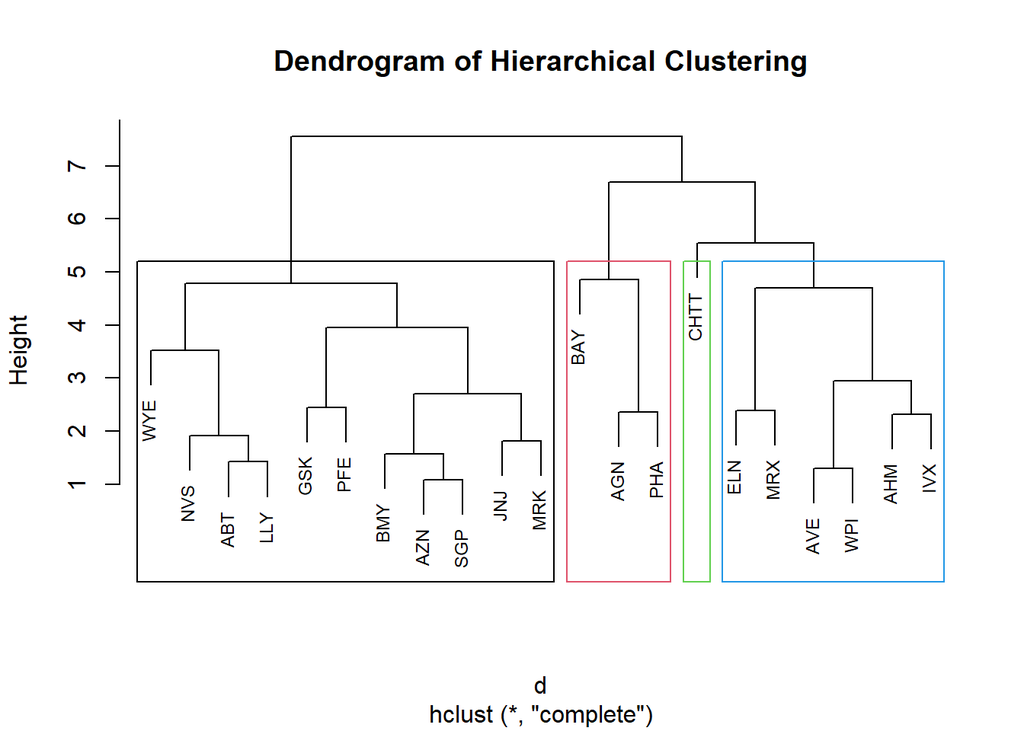

```r
# Get the euclidean distance for the data
d <- dist(scaled.data, method = "euclidean")

# Hierarchical Clustering
hc <- hclust(d, method = "complete")

# Visualize the output Dendrogram at height=5
plot(hc, cex = 0.75, main = "Dendrogram of Hierarchical Clustering")
rect.hclust(hc, h=5, border = 1:4)
```

in hierarchical clustering, we have considered the height h=5. because at h=5 the clusters are formed correspond to the distance between the merged clusters compared to remaining heights. at this height 4 clusters are formed. from the dendrogram we can say that first cluster with size 11 second cluster with size 3 third cluster with size 1 fourth cluster with size 6 but here in this clustering, one cluster have many points and the other have too less, so this might not be a good one to do clustering of all the companies.

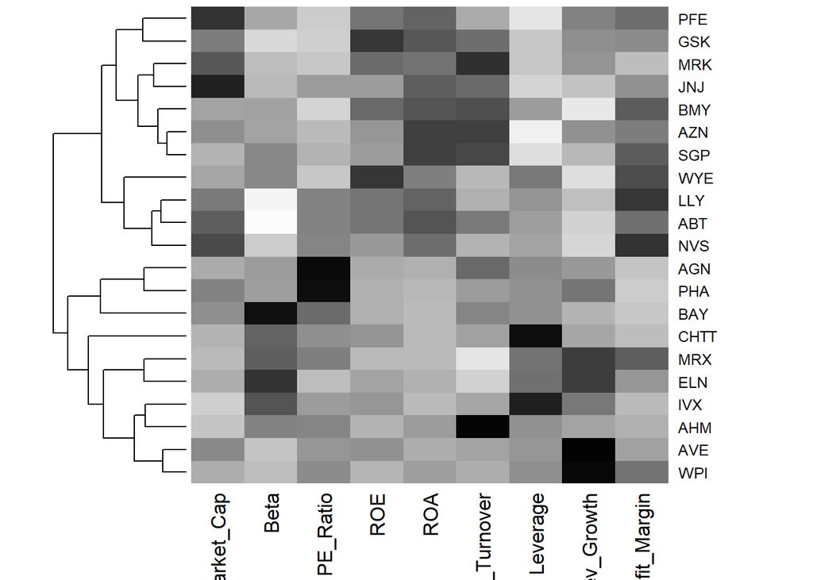

```r
heatmap(as.matrix(scaled.data), Colv = NA, hclustfun = hclust,
        col=rev(paste("gray",1:99,sep="")))
```

Out of all these clusters I have found that Kmeans clustering with no.of clusters as 5 produce better clusters. **************

2. Interpret the clusters with respect to the numerical variables used in forming the clusters. Is there a pattern in the clusters with respect to the numerical variables (10 to 12)?

```r
# creating a table with clusters
clustered.data1 <- pharma.data[,c(2:11)]  %>%
                   mutate(cluster=k_sil$cluster) %>% arrange(cluster, ascending = T)
# dataset with clusters
clustered.data1
```

```
##                                    Name Market_Cap Beta PE_Ratio  ROE  ROA
## AVE                             Aventis      47.16 0.32     20.1 21.8  7.5
## ELN               Elan Corporation, plc       0.78 1.08      3.6 15.1  5.1
## MRX  Medicis Pharmaceutical Corporation       1.20 0.75     28.6 11.2  5.4
## WPI        Watson Pharmaceuticals, Inc.       3.26 0.24     18.4 10.2  6.8
## AGN                      Allergan, Inc.       7.58 0.41     82.5 12.9  5.5
## PHA               Pharmacia Corporation      56.24 0.40     56.5 13.5  5.7
## GSK                 GlaxoSmithKline plc     122.11 0.35     18.0 62.9 20.3
## JNJ                   Johnson & Johnson     173.93 0.46     28.4 28.6 16.3
## MRK                   Merck & Co., Inc.     132.56 0.46     18.9 40.6 15.0
## PFE                          Pfizer Inc     199.47 0.65     23.6 45.6 19.2
## BAY                            Bayer AG      16.90 1.11     27.9  3.9  1.4
## CHTT                       Chattem, Inc       0.41 0.85     26.0 24.1  4.3
## IVX                    IVAX Corporation       2.60 0.65     19.9 21.4  6.8
## ABT                 Abbott Laboratories      68.44 0.32     24.7 26.4 11.8
## AHM                        Amersham plc       6.30 0.46     20.7 14.9  7.8
## AZN                     AstraZeneca PLC      67.63 0.52     21.5 27.4 15.4
## BMY        Bristol-Myers Squibb Company      51.33 0.50     13.9 34.8 15.1
## LLY               Eli Lilly and Company      73.84 0.18     27.9 31.0 13.5
## NVS                         Novartis AG      96.65 0.19     21.6 17.9 11.2
## SGP         Schering-Plough Corporation      34.10 0.51     18.9 22.6 13.3
## WYE                               Wyeth      48.19 0.63     13.1 54.9 13.4
##      Asset_Turnover Leverage Rev_Growth Net_Profit_Margin cluster
## AVE             0.6     0.34      26.81              12.9       1
## ELN             0.3     1.07      34.21              13.3       1
## MRX             0.3     0.93      30.37              21.3       1
## WPI             0.5     0.20      29.18              15.1       1
## AGN             0.9     0.60       9.16               5.5       2
## PHA             0.6     0.35      15.00               7.3       2
## GSK             1.0     0.34      21.87              21.1       3
## JNJ             0.9     0.10       9.37              17.9       3
## MRK             1.1     0.28      17.35              14.1       3
## PFE             0.8     0.16      25.54              25.2       3
## BAY             0.6     0.00      -3.17               2.6       4
## CHTT            0.6     3.51       6.38               7.5       4
## IVX             0.6     1.45      13.99              11.0       4
## ABT             0.7     0.42       7.54              16.1       5
## AHM             0.9     0.27       7.05              11.2       5
## AZN             0.9     0.00      15.00              18.0       5
## BMY             0.9     0.57       2.70              20.6       5
## LLY             0.6     0.53       6.21              23.4       5
## NVS             0.5     0.06      -2.69              22.4       5
## SGP             0.8     0.00       8.56              17.6       5
## WYE             0.6     1.12       0.36              25.5       5
```

```r
cat("below are the list of firms with their corresponding clusters")
```

```
## below are the list of firms with their corresponding clusters
```

```r
clustered.data1[,c(1,11)]
```

```
##                                    Name cluster
## AVE                             Aventis       1
## ELN               Elan Corporation, plc       1
## MRX  Medicis Pharmaceutical Corporation       1
## WPI        Watson Pharmaceuticals, Inc.       1
## AGN                      Allergan, Inc.       2
## PHA               Pharmacia Corporation       2
## GSK                 GlaxoSmithKline plc       3
## JNJ                   Johnson & Johnson       3
## MRK                   Merck & Co., Inc.       3
## PFE                          Pfizer Inc       3
## BAY                            Bayer AG       4
## CHTT                       Chattem, Inc       4
## IVX                    IVAX Corporation       4
## ABT                 Abbott Laboratories       5
## AHM                        Amersham plc       5
## AZN                     AstraZeneca PLC       5
## BMY        Bristol-Myers Squibb Company       5
## LLY               Eli Lilly and Company       5
## NVS                         Novartis AG       5
## SGP         Schering-Plough Corporation       5
## WYE                               Wyeth       5
```

calculate the mean of all numerical variables in each cluster

```r
# calculate the mean of all numerical variables
aggregate(scaled.data, by=list(k_sil$cluster), FUN=mean)
```

```
##   Group.1  Market_Cap       Beta    PE_Ratio        ROE        ROA
## 1       1 -0.76022489  0.2796041 -0.47742380 -0.7438022 -0.8107428
## 2       2 -0.43925134 -0.4701800  2.70002464 -0.8349525 -0.9234951
## 3       3  1.69558112 -0.1780563 -0.19845823  1.2349879  1.3503431
## 4       4 -0.87051511  1.3409869 -0.05284434 -0.6184015 -1.1928478
## 5       5 -0.03142211 -0.4360989 -0.31724852  0.1950459  0.4083915
##   Asset_Turnover    Leverage Rev_Growth Net_Profit_Margin
## 1     -1.2684804  0.06308085  1.5180158      -0.006893899
## 2      0.2306328 -0.14170336 -0.1168459      -1.416514761
## 3      1.1531640 -0.46807818  0.4671788       0.591242521
## 4     -0.4612656  1.36644699 -0.6912914      -1.320000179
## 5      0.1729746 -0.27449312 -0.7041516       0.556954446
```

Adding the cluster to normalised data.

```r
# add the clusters to the scaled data
scaled.data1 <- data.frame(scaled.data, k_sil$cluster)
scaled.data1
```

```
##      Market_Cap        Beta    PE_Ratio         ROE        ROA Asset_Turnover
## ABT   0.1840960 -0.80125356 -0.04671323  0.04009035  0.2416121      0.0000000
## AGN  -0.8544181 -0.45070513  3.49706911 -0.85483986 -0.9422871      0.9225312
## AHM  -0.8762600 -0.25595600 -0.29195768 -0.72225761 -0.5100700      0.9225312
## AZN   0.1702742 -0.02225704 -0.24290879  0.10638147  0.9181259      0.9225312
## AVE  -0.1790256 -0.80125356 -0.32874435 -0.26484883 -0.5664461     -0.4612656
## BAY  -0.6953818  2.27578267  0.14948233 -1.45146000 -1.7127612     -0.4612656
## BMY  -0.1078688 -0.10015669 -0.70887325  0.59693581  0.8617498      0.9225312
## CHTT -0.9767669  1.26308721  0.03299122 -0.11237924 -1.1677918     -0.4612656
## ELN  -0.9704532  2.15893320 -1.34037772 -0.70899938 -1.0174553     -1.8450624
## LLY   0.2762415 -1.34655112  0.14948233  0.34502953  0.5610770     -0.4612656
## GSK   1.0999201 -0.68440408 -0.45749769  2.45971647  1.8389364      1.3837968
## IVX  -0.9393967  0.48409069 -0.34100657 -0.29136529 -0.6979905     -0.4612656
## JNJ   1.9841758 -0.25595600  0.18013789  0.18593083  1.0872544      0.9225312
## MRX  -0.9632863  0.87358895  0.19240011 -0.96753478 -0.9610792     -1.8450624
## MRK   1.2782387 -0.25595600 -0.40231769  0.98142435  0.8429577      1.8450624
## NVS   0.6654710 -1.30760129 -0.23677768 -0.52338423  0.1288598     -0.9225312
## PFE   2.4199899  0.48409069 -0.11415545  1.31287998  1.6322239      0.4612656
## PHA  -0.0240846 -0.48965495  1.90298017 -0.81506519 -0.9047030     -0.4612656
## SGP  -0.4018812 -0.06120687 -0.40231769 -0.21181593  0.5234929      0.4612656
## WPI  -0.9281345 -1.11285216 -0.43297324 -1.03382590 -0.6979905     -0.9225312
## WYE  -0.1614497  0.40619104 -0.75792214  1.92938746  0.5422849     -0.4612656
##         Leverage  Rev_Growth Net_Profit_Margin k_sil.cluster
## ABT  -0.21209793 -0.52776752        0.06168225             5
## AGN   0.01828430 -0.38113909       -1.55366706             2
## AHM  -0.40408312 -0.57211809       -0.68503583             5
## AZN  -0.74965647  0.14744734        0.35122600             5
## AVE  -0.31449003  1.21638667       -0.42597037             1
## BAY  -0.74965647 -1.49714434       -1.99560225             4
## BMY  -0.02011273 -0.96584257        0.74744375             5
## CHTT  3.74279705 -0.63276071       -1.24888417             4
## ELN   0.61983791  1.88617085       -0.36501379             1
## LLY  -0.07130879 -0.64814764        1.17413980             5
## GSK  -0.31449003  0.76926048        0.82363947             3
## IVX   1.10620040  0.05603085       -0.71551412             4
## JNJ  -0.62166634 -0.36213170        0.33598685             3
## MRX   0.44065173  1.53860717        0.85411776             1
## MRK  -0.39128411  0.36014907       -0.24310064             3
## NVS  -0.67286239 -1.45369888        1.02174835             5
## PFE  -0.54487226  1.10143723        1.44844440             3
## PHA  -0.30169102  0.14744734       -1.27936246             2
## SGP  -0.74965647 -0.43544591        0.29026942             5
## WPI  -0.49367621  1.43089863       -0.09070919             1
## WYE   0.68383297 -1.17763919        1.49416183             5
```

by comparing the mean values of all the numerical variables from the clusters Cluster1 with companies AVE, WPI, MRX, ELN has high revenue growth and beta value. but have low asset turnover, return on equity and return on asset.And the market capitalization is also relatively low. based on these, it is possible that these companies are still growing and they are at early stage. These companies might be investing heavily in marketing and sales. However, the high revenue growth and beta value suggest that they are expected to improve their earnings more rapidly in the coming days. these companies are distinguished by their higher growth potential and low profitability.

Cluster2 with companies PHA, AGN has high Price or earnings ratio and asset turnover, but have low net profit margin, return on equity and return on asset. and the market capitalization is also relatively low. However, the high asset turnover and price or earnings ratios suggest that they are expected to improve their earnings more rapidly in the future, while having little net profit in the past. However, with its high price, investors get more risk.

# Is there a pattern in the clusters with respect to the numerical variables (10 to12)

```r
# Add the clusters to the data
data_pattern <- pharma.data[12:14] %>% mutate(Clusters = k_sil$cluster)
data_pattern
```

```
##      Median_Recommendation    Location Exchange Clusters
## ABT           Moderate Buy          US     NYSE        5
## AGN           Moderate Buy      CANADA     NYSE        2
## AHM             Strong Buy          UK     NYSE        5
## AZN          Moderate Sell          UK     NYSE        5
## AVE           Moderate Buy      FRANCE     NYSE        1
## BAY                   Hold     GERMANY     NYSE        4
## BMY          Moderate Sell          US     NYSE        5
## CHTT          Moderate Buy          US   NASDAQ        4
## ELN          Moderate Sell     IRELAND     NYSE        1
## LLY                   Hold          US     NYSE        5
## GSK                   Hold          UK     NYSE        3
## IVX                   Hold          US     AMEX        4
## JNJ           Moderate Buy          US     NYSE        3
## MRX           Moderate Buy          US     NYSE        1
## MRK                   Hold          US     NYSE        3
## NVS                   Hold SWITZERLAND     NYSE        5
## PFE           Moderate Buy          US     NYSE        3
## PHA                   Hold          US     NYSE        2
## SGP                   Hold          US     NYSE        5
## WPI          Moderate Sell          US     NYSE        1
## WYE                   Hold          US     NYSE        5
```

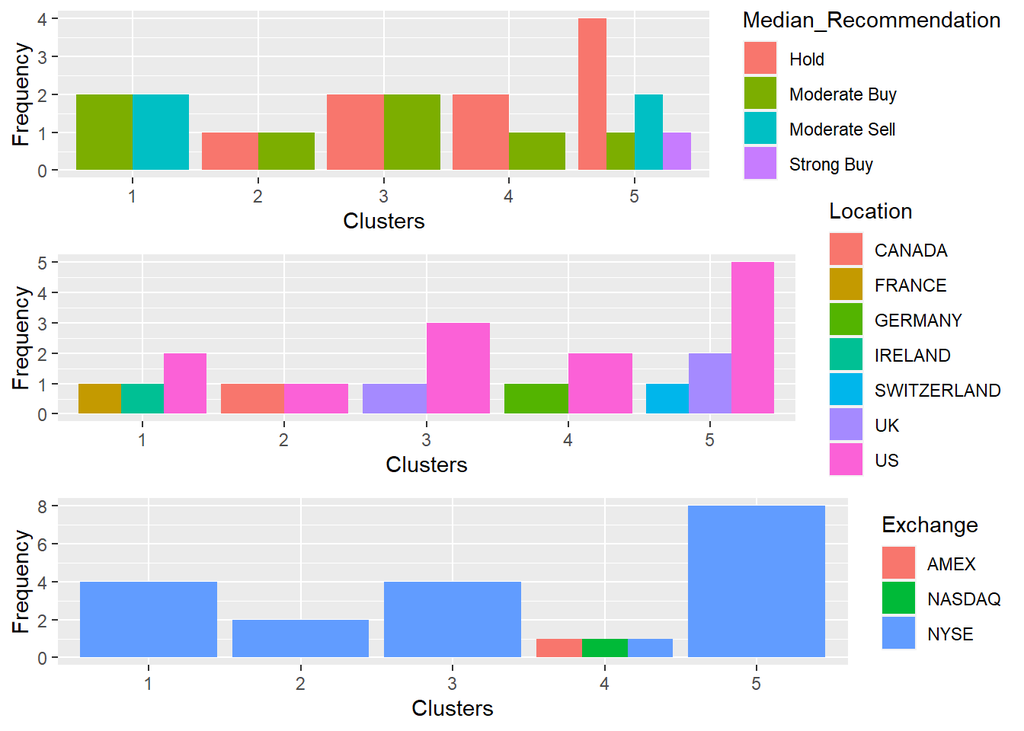

```r
# Plot the data with Median_Recommendation
recommendation <- ggplot(data_pattern, mapping = aes(factor(Clusters), fill =Median_Recommendation)) + geom_bar(position='dodge') + labs(x ='Clusters',y = 'Frequency')

# Plot the data with location
location <- ggplot(data_pattern, mapping = aes(factor(Clusters), fill = Location)) + geom_bar(position = 'dodge') + labs(x='Clusters',y = 'Frequency')

# Plot the data with Exchange
exchange <- ggplot(data_pattern, mapping = aes(factor(Clusters), fill = Exchange)) + geom_bar(position = 'dodge') + labs(x='Clusters',y = 'Frequency')

grid.arrange(recommendation, location, exchange)
```

Cluster1, Recommended as Moderate Buy and Moderate Sell from Locations France, Ireland and US and listed under NYSE.

Cluster2, Recommended as Hold and Moderate Buy from Locations US and canada and listed under NYSE.

Cluster3, Recommended as Hold and Moderate Buy from Locations UK and US and listed under NYSE.

Cluster4, Recommended as Hold and Moderate Buy from Locations Germany and US and listed under AMEX, NASDAQ and NYSE.

Cluster5, Recommended Hold, Moderate Sell, Strong Buy & Moderate Buy from Locations Switzerland, UK and US and listed under NYSE. *************** 3.Provide an appropriate name for each cluster using any or all of the variables in the dataset. A. Appropriate names for the clusters: Cluster1: High Growth potential Cluster2: High Risk High Reward Cluster3: Stability and Profitability Cluster4: High Risk High Beta Cluster5: Low Risk High Profitability